# Predicting the Super Bowl

Jason Ramsland

[figure not shown]

# Introduction

The Super Bowl is the final championship game of the National Football League, where the AFC champions face off against the NFC champions. It is the biggest Televised event in the United States every year. More information on the Super bowl can be found [here](https://www.refresheverything.com/super-bowl/). In this tutorial, we will explore Super Bowl data dating back to the first Super Bowl in 1967, to the most recent one this past year in 2022. The game has changed jurassicly over the years, from new rules being enforced to new styles of play and coaching philosophies, NFL games of today look much different than it did back in 1967. These changes provide us with motivation to see how these instances of change have affected Super Bowl performances. From this tutorial, football fans will gain new insights on current trends that exist in the sport they love, and non-football fans will learn why modern day football might be more exciting than it has ever been before.

We will start by importing a dataset found [here](https://www.kaggle.com/datasets/timoboz/superbowl-history-1967-2020?datasetId=499772&searchQuery=predi), which includes the date, location (stadium, city, and state), winning team, losing team, points scored by both teams, and the Super bowl number.

# Data Curation and Exploratory Data Analysis

```python
import pandas as pd

df = pd.read_csv("superbowl.csv")
df.head()
```

|  | Date | SB | Winner | Winner Pts | Loser | Loser Pts | MVP | Stadium | City | State |
| --- | --- | --- | --- | --- | --- | --- | --- | --- | --- | --- |
| 0 | Feb 2 2020 | LIV (54) | Kansas City Chiefs | 31 | San Francisco 49ers | 20 | Patrick Mahomes | Hard Rock Stadium | Miami Gardens | Florida |
| 1 | Feb 3 2019 | LIII (53) | New England Patriots | 13 | Los Angeles Rams | 3 | Julian Edelman | Mercedes-Benz Stadium | Atlanta | Georgia |
| 2 | Feb 4 2018 | LII (52) | Philadelphia Eagles | 41 | New England Patriots | 33 | Nick Foles | U.S. Bank Stadium | Minneapolis | Minnesota |
| 3 | Feb 5 2017 | LI (51) | New England Patriots | 34 | Atlanta Falcons | 28 | Tom Brady | NRG Stadium | Houston | Texas |
| 4 | Feb 7 2016 | 50 | Denver Broncos | 24 | Carolina Panthers | 10 | Von Miller | Levi's Stadium | Santa Clara | California |

We can see that the dataset only covers data up to 2020, so we need to add the 2021 and 2022 data manually.

```python
temp = pd.DataFrame({'Date':['Feb 7 2021', 'Feb 13 2022'],
                     'SB':['LV (55)', 'LVI (56)'],
                     'Winner':['Tampa Bay Buccaneers', 'Los Angeles Rams'],
                     'Winner Pts':[31, 23],
                     'Loser':['Kansas City Chiefs', 'Cincinnati Bengals'],
                     'Loser Pts':[9, 20],
                     'MVP':['Tom Brady', 'Cooper Kupp'],
                     'Stadium':['Raymond James Stadium', 'SoFi Stadium'],
                     'City':['Tampa', 'Inglewood'],
                     'State':['Florida', 'California']})
# Reverse order of the rows then append the new data
df = df[::-1]
df = pd.concat([df,temp], ignore_index=True)
# Reverse order of the rows once again to have the latest Super bowl data at the head of the dataframe
df = df[::-1]
df.head()
```

|  | Date | SB | Winner | Winner Pts | Loser | Loser Pts | MVP | Stadium | City | State |
| --- | --- | --- | --- | --- | --- | --- | --- | --- | --- | --- |
| 55 | Feb 13 2022 | LVI (56) | Los Angeles Rams | 23 | Cincinnati Bengals | 20 | Cooper Kupp | SoFi Stadium | Inglewood | California |
| 54 | Feb 7 2021 | LV (55) | Tampa Bay Buccaneers | 31 | Kansas City Chiefs | 9 | Tom Brady | Raymond James Stadium | Tampa | Florida |
| 53 | Feb 2 2020 | LIV (54) | Kansas City Chiefs | 31 | San Francisco 49ers | 20 | Patrick Mahomes | Hard Rock Stadium | Miami Gardens | Florida |
| 52 | Feb 3 2019 | LIII (53) | New England Patriots | 13 | Los Angeles Rams | 3 | Julian Edelman | Mercedes-Benz Stadium | Atlanta | Georgia |
| 51 | Feb 4 2018 | LII (52) | Philadelphia Eagles | 41 | New England Patriots | 33 | Nick Foles | U.S. Bank Stadium | Minneapolis | Minnesota |

Lets first analyze the MVPs.

```python
df["MVP"].unique() # Shows all SB MVPs in the history of the sport
```

```
array(['Cooper Kupp', 'Tom Brady', 'Patrick Mahomes', 'Julian Edelman',
       'Nick Foles', 'Von Miller', 'Malcolm Smith', 'Joe Flacco',
       'Eli Manning', 'Aaron Rodgers', 'Drew Brees', 'Santonio Holmes',
       'Peyton Manning', 'Hines Ward', 'Deion Branch', 'Dexter Jackson',
       'Ray Lewis+', 'Kurt Warner+', 'John Elway+', 'Terrell Davis+',
       'Desmond Howard', 'Larry Brown', 'Steve Young+', 'Emmitt Smith+',
       'Troy Aikman+', 'Mark Rypien', 'Ottis Anderson', 'Joe Montana+',
       'Jerry Rice+', 'Doug Williams', 'Phil Simms', 'Richard Dent+',
       'Marcus Allen+', 'John Riggins+', 'Jim Plunkett',
       'Terry Bradshaw+', 'Harvey MartinRandy White+',
       'Fred Biletnikoff+', 'Lynn Swann+', 'Franco Harris+',
       'Larry Csonka+', 'Jake Scott', 'Roger Staubach+', 'Chuck Howley',
       'Len Dawson+', 'Joe Namath+', 'Bart Starr+'], dtype=object)
```

```python
mvp_count = pd.DataFrame(df['MVP'].value_counts())
mvp_count.head(10)
```

|  | MVP |
| --- | --- |
| Tom Brady | 5 |
| Joe Montana+ | 3 |
| Eli Manning | 2 |
| Terry Bradshaw+ | 2 |
| Bart Starr+ | 2 |
| Roger Staubach+ | 1 |
| John Riggins+ | 1 |
| Ottis Anderson | 1 |
| Joe Namath+ | 1 |
| Jerry Rice+ | 1 |

We see that Tom Brady, Joe Montana, Eli Manning, Terry Bradshaw, and Bart Starr are the only players to win multiple Super Bowl MVPs. All five of these players play the quarterback position. Lets look at the MVP winners based on the position they play. To do this, we will import another dataset (found [here](https://www.kaggle.com/datasets/rafabelokurows/mvps-of-the-superbowl-19672020)) that includes the position played by the MVP of each Super bowl.

```python
pos_df = pd.read_csv("mvpsb[1].csv") # New dataset
pos_df.tail()
```

|  | SB | PLAYER | POSITION | TEAM |
| --- | --- | --- | --- | --- |
| 49 | 50 | Von Miller | LB | Denver |
| 50 | LI (51) | Tom Brady | QB | New England |
| 51 | LII (52) | Nick Foles | QB | Philadelphia |
| 52 | LIII (53) | Julian Edelman | WR | New England |
| 53 | LIV (54) | Patrick Mahomes | QB | Kansas City |

Once again, we must add data from 2021 and 2022.

```python
temp = pd.DataFrame({'SB':['LV (55)', 'LVI (56)'],
                     'PLAYER':['Tom Brady', 'Cooper Kupp'],
                     'POSITION':['QB', 'WR'],
                     'TEAM':['Tampa Bay Buccaneers', 'Los Angeles Rams']})
pos_df = pd.concat([pos_df,temp], ignore_index=True)
pos_df.tail()
```

|  | SB | PLAYER | POSITION | TEAM |
| --- | --- | --- | --- | --- |
| 51 | LII (52) | Nick Foles | QB | Philadelphia |
| 52 | LIII (53) | Julian Edelman | WR | New England |
| 53 | LIV (54) | Patrick Mahomes | QB | Kansas City |
| 54 | LV (55) | Tom Brady | QB | Tampa Bay Buccaneers |
| 55 | LVI (56) | Cooper Kupp | WR | Los Angeles Rams |

```python
# Reverse the order to match our existing dataframe
pos_df = pos_df[::-1]
pos_df.head()
```

|  | SB | PLAYER | POSITION | TEAM |
| --- | --- | --- | --- | --- |
| 55 | LVI (56) | Cooper Kupp | WR | Los Angeles Rams |
| 54 | LV (55) | Tom Brady | QB | Tampa Bay Buccaneers |
| 53 | LIV (54) | Patrick Mahomes | QB | Kansas City |
| 52 | LIII (53) | Julian Edelman | WR | New England |
| 51 | LII (52) | Nick Foles | QB | Philadelphia |

```python
# Combine dataframes
df = pd.merge(df, pos_df, on = "SB")
df.head()
```

|  | Date | SB | Winner | Winner Pts | Loser | Loser Pts | MVP | Stadium | City | State | PLAYER | POSITION | TEAM |
| --- | --- | --- | --- | --- | --- | --- | --- | --- | --- | --- | --- | --- | --- |
| 0 | Feb 13 2022 | LVI (56) | Los Angeles Rams | 23 | Cincinnati Bengals | 20 | Cooper Kupp | SoFi Stadium | Inglewood | California | Cooper Kupp | WR | Los Angeles Rams |
| 1 | Feb 7 2021 | LV (55) | Tampa Bay Buccaneers | 31 | Kansas City Chiefs | 9 | Tom Brady | Raymond James Stadium | Tampa | Florida | Tom Brady | QB | Tampa Bay Buccaneers |
| 2 | Feb 2 2020 | LIV (54) | Kansas City Chiefs | 31 | San Francisco 49ers | 20 | Patrick Mahomes | Hard Rock Stadium | Miami Gardens | Florida | Patrick Mahomes | QB | Kansas City |
| 3 | Feb 3 2019 | LIII (53) | New England Patriots | 13 | Los Angeles Rams | 3 | Julian Edelman | Mercedes-Benz Stadium | Atlanta | Georgia | Julian Edelman | WR | New England |
| 4 | Feb 4 2018 | LII (52) | Philadelphia Eagles | 41 | New England Patriots | 33 | Nick Foles | U.S. Bank Stadium | Minneapolis | Minnesota | Nick Foles | QB | Philadelphia |

```python
# Rename POSITION column and remove redundant columns
df = df.rename(columns = {"POSITION":"MVP_Position"})
df = df.drop('PLAYER', axis=1)
df = df.drop('TEAM', axis=1)
df.head()
```

|  | Date | SB | Winner | Winner Pts | Loser | Loser Pts | MVP | Stadium | City | State | MVP_Position |
| --- | --- | --- | --- | --- | --- | --- | --- | --- | --- | --- | --- |
| 0 | Feb 13 2022 | LVI (56) | Los Angeles Rams | 23 | Cincinnati Bengals | 20 | Cooper Kupp | SoFi Stadium | Inglewood | California | WR |
| 1 | Feb 7 2021 | LV (55) | Tampa Bay Buccaneers | 31 | Kansas City Chiefs | 9 | Tom Brady | Raymond James Stadium | Tampa | Florida | QB |
| 2 | Feb 2 2020 | LIV (54) | Kansas City Chiefs | 31 | San Francisco 49ers | 20 | Patrick Mahomes | Hard Rock Stadium | Miami Gardens | Florida | QB |
| 3 | Feb 3 2019 | LIII (53) | New England Patriots | 13 | Los Angeles Rams | 3 | Julian Edelman | Mercedes-Benz Stadium | Atlanta | Georgia | WR |
| 4 | Feb 4 2018 | LII (52) | Philadelphia Eagles | 41 | New England Patriots | 33 | Nick Foles | U.S. Bank Stadium | Minneapolis | Minnesota | QB |

```python
# Create table showing the number of MVPs by position
mvp_pos_count = pd.DataFrame(df['MVP_Position'].value_counts()).reset_index()
mvp_pos_count
```

|  | index | MVP_Position |
| --- | --- | --- |
| 0 | QB | 31 |
| 1 | WR | 8 |
| 2 | RB | 6 |
| 3 | LB | 4 |
| 4 | CB | 2 |
| 5 | KR | 1 |
| 6 | DE | 1 |
| 7 | DL | 1 |
| 8 | FB | 1 |
| 9 | S | 1 |

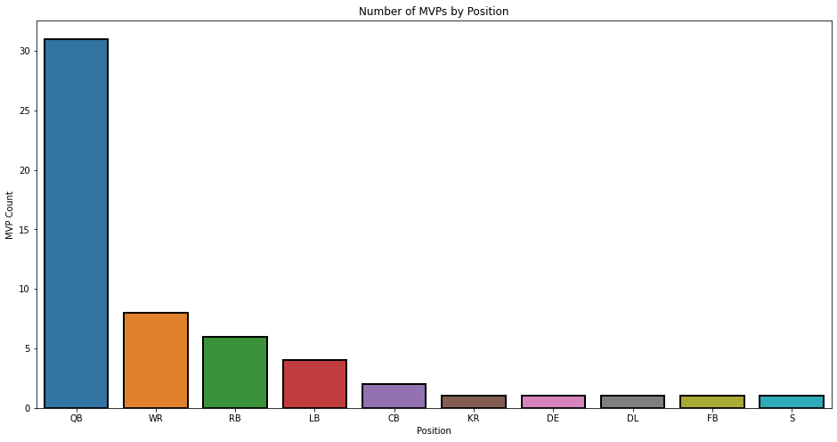

```python
import matplotlib.pyplot as plt
import seaborn as sns

# Display findings as a bar graph
plt.figure(figsize=(16, 8))
graph = sns.barplot(x='index', y='MVP_Position', data=mvp_pos_count, edgecolor='black', linewidth=2)
graph.set_title('Number of MVPs by Position')
graph.set(xlabel='Position', ylabel='MVP Count')
plt.show()
```

We can see from the bar graph that quarterback is by far the most common position to win MVP. There are also multiple instances of wide recievers, running backs, linebackers, and cornerbacks who have won it.

```python
df.describe()
```

|  | Winner Pts | Loser Pts |
| --- | --- | --- |
| count | 56.000000 | 56.000000 |
| mean | 30.000000 | 16.142857 |
| std | 9.635163 | 7.359418 |
| min | 13.000000 | 3.000000 |
| 25% | 23.000000 | 10.000000 |
| 50% | 30.500000 | 17.000000 |
| 75% | 35.000000 | 21.000000 |
| max | 55.000000 | 33.000000 |

We see that the mean winner's points scored is nearly double the mean loser's points scored, so lets investigate this further.

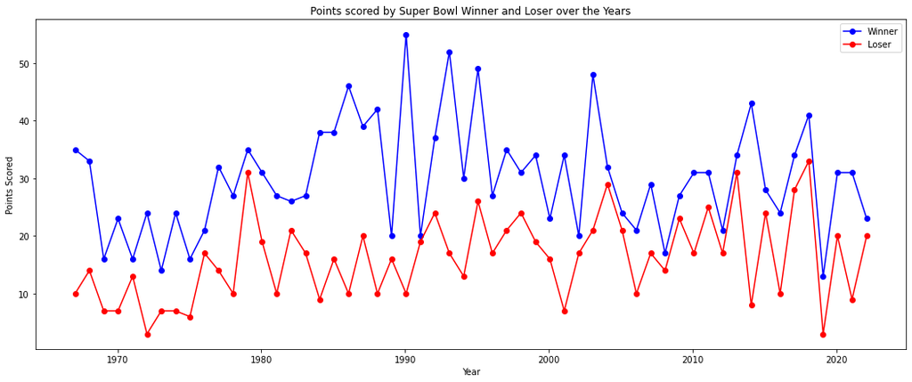

```python
import matplotlib.pyplot as plt

df['Date'] = pd.to_datetime(df['Date'])

# Display line graphs of points scored by the winning and losing team over the years
fig, ax = plt.subplots(figsize=(18,7))
ax.plot(df['Date'], df['Winner Pts'], marker='.', mew=4, color='blue', label='Winner')
ax.plot(df['Date'], df['Loser Pts'], marker='.', color='red', label='Loser', mew=4)
ax.set_xlabel('Year')
ax.set_ylabel('Points Scored')
ax.set_title('Points scored by Super Bowl Winner and Loser over the Years')
ax.legend()
plt.show()
```

Now that we have a graph of the points scored, and data on the MVPs over the years, lets combine the two into a graph that displays both.

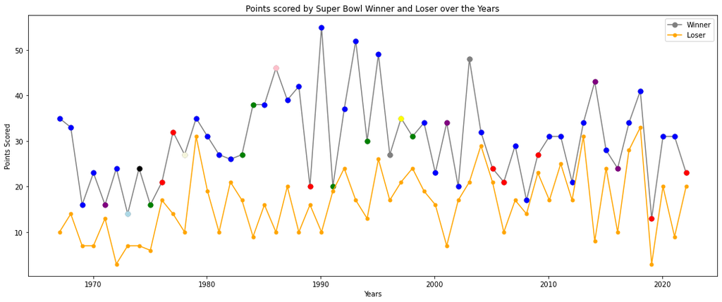

```python
fig, ax = plt.subplots(figsize=(18,7))
ax.plot(df['Date'], df['Winner Pts'], marker='.', mew=5, color='gray', label='Winner')

# Plot each point a different color based on which position won MVP
for i in range(0,56):
    if (df.iloc[i, 10]) == "QB":
        ax.plot(df.iloc[i, 0], df.iloc[i, 3], marker='.', mew=5, color='blue')     # Quarterback = blue
    if (df.iloc[i, 10]) == "WR":
        ax.plot(df.iloc[i, 0], df.iloc[i, 3], marker='.', mew=5, color='red')      # Wide reciever = red
    if (df.iloc[i, 10]) == "RB":
        ax.plot(df.iloc[i, 0], df.iloc[i, 3], marker='.', mew=5, color='green')    # Running back = green
    if (df.iloc[i, 10]) == "FB":
        ax.plot(df.iloc[i, 0], df.iloc[i, 3], marker='.', mew=5, color='black')    # Fullback = black
    if (df.iloc[i, 10]) == "KR":
        ax.plot(df.iloc[i, 0], df.iloc[i, 3], marker='.', mew=5, color='yellow')   # Kick returner = yellow
    if (df.iloc[i, 10]) == "LB":
        ax.plot(df.iloc[i, 0], df.iloc[i, 3], marker='.', mew=5, color='purple')   # Linebacker = purple
    if (df.iloc[i, 10]) == "CB":
        ax.plot(df.iloc[i, 0], df.iloc[i, 3], marker='.', mew=5, color='grey')     # Cornerback = grey
    if (df.iloc[i, 10]) == "DE":
        ax.plot(df.iloc[i, 0], df.iloc[i, 3], marker='.', mew=5, color='pink')     # Defensive end = pink
    if (df.iloc[i, 10]) == "DL":
        ax.plot(df.iloc[i, 0], df.iloc[i, 3], marker='.', mew=5, color='beige')    # Defensive lineman = beige
    if (df.iloc[i, 10]) == "S":
        ax.plot(df.iloc[i, 0], df.iloc[i, 3], marker='.', mew=5, color='lightblue')# Safety = lightblue

ax.plot(df['Date'],df['Loser Pts'], marker='.', color='orange', label='Loser', mew=3)
ax.set_xlabel('Years')
ax.set_ylabel('Points Scored')
ax.set_title('Points scored by Super Bowl Winner and Loser over the Years')
ax.legend()
plt.show()
```

This graph displays a lot of information, however it is hard to decypher, so lets instead simplify it so we are not dealing with so many variables. We will group all positions categorically based on the side of the ball they play on. Blue plots will represent all offensive positions, red plots will represent all defensive positions, and green plots will represent all special teams positions.

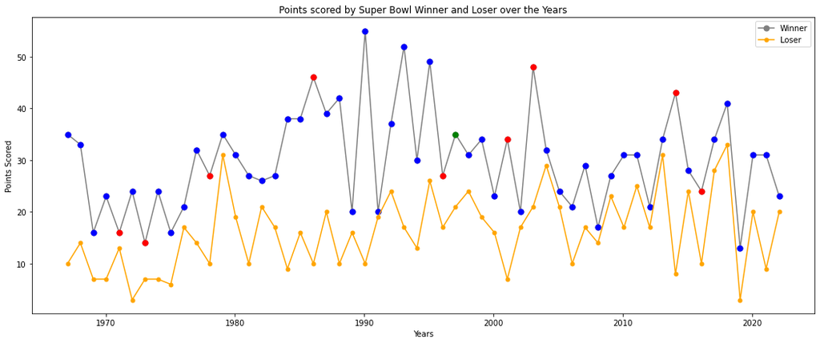

```python
fig, ax = plt.subplots(figsize=(18,7))
ax.plot(df['Date'], df['Winner Pts'], marker='.', mew=5, color='gray', label='Winner')

for i in range(0,56):

    # Offense:
    if (df.iloc[i, 10] == "QB") or (df.iloc[i, 10] == "WR") or (df.iloc[i, 10] == "RB") \
        or (df.iloc[i, 10] == "FB"):

        ax.plot(df.iloc[i, 0], df.iloc[i, 3], marker='.', mew=5, color='blue')

    # Defense:
    if (df.iloc[i, 10] == "LB") or (df.iloc[i, 10] == "CB") or (df.iloc[i, 10] == "DE") \
        or (df.iloc[i, 10] == "DL") or (df.iloc[i, 10] == "S"):

        ax.plot(df.iloc[i, 0], df.iloc[i, 3], marker='.', mew=5, color='red')

    # Special Teams:
    if (df.iloc[i, 10]) == "KR":

        ax.plot(df.iloc[i, 0], df.iloc[i, 3], marker='.', mew=5, color='green')

ax.plot(df['Date'],df['Loser Pts'], marker='.', color='orange', label='Loser', mew=3)
ax.set_xlabel('Years')
ax.set_ylabel('Points Scored')
ax.set_title('Points scored by Super Bowl Winner and Loser over the Years')
ax.legend()
plt.show()
```

This plot is much easier to read. We can see that there is only one instance of a special teams player winning MVP, and this was in 1997. We also see that although offensive players have generally dominated winning MVP, there is a fairly even scattering of defensive players who have won it over the years, and the most recent occurrence of this was in 2016 when linebacker Von Miller won it. I was expecting to see correlation between low scoring games leading to defensive players winning MVP, and high scoring games leading to offensive players winning MVP. However, we can see that this is not the case considering that 2003 was a high scoring game but a defensive player won MVP, and alternatively 2019 was a low scoring game and an offensive player won MVP.

Since we were not able to find correlation between points scored and MVP position, lets instead look at the point differential over the years.

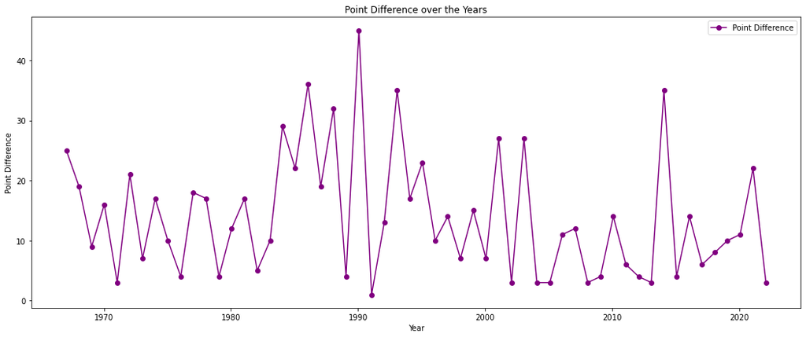

```python
fig, ax = plt.subplots(figsize=(18,7))

ax.plot(df['Date'],df['Winner Pts']-df['Loser Pts'], marker='.', color='purple', label='Point Difference', mew=4)
ax.set_xlabel('Year')
ax.set_ylabel('Point Difference')
ax.set_title('Point Difference over the Years')
ax.legend()
plt.show()
```

Lets adjust this graph to instead show a scatter plot with a regression line.

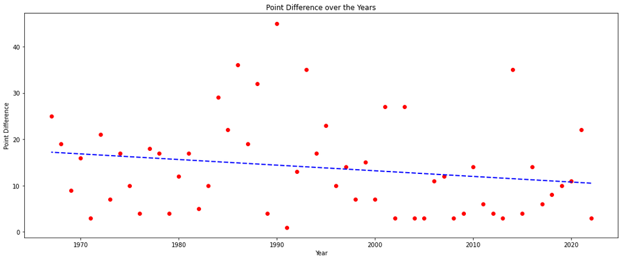

```python
import numpy as np

dates=[]
diff=[]
for i in range (0,56): # Calculate year and differential for each row
    dates.append(2022-i)
    diff.append(df.iloc[i,3] - df.iloc[i,5])
x = np.array(dates)
y = np.array(diff)
a, b = np.polyfit(x, y, 1)
fig, ax = plt.subplots(figsize=(18,7))
plt.scatter(x, y, color='red')
# Regression line
plt.plot(x, a*x+b, color='blue', linestyle='--', linewidth=2)
ax.set_xlabel('Year')
ax.set_ylabel('Point Difference')
ax.set_title('Point Difference over the Years')
plt.show()
```

We can see that there is some negative correlation of point differential over time. However, considering there are several outliers around 1990, lets break up this plot into 5 subplots to get a better understanding on how the point differential has changed over time.

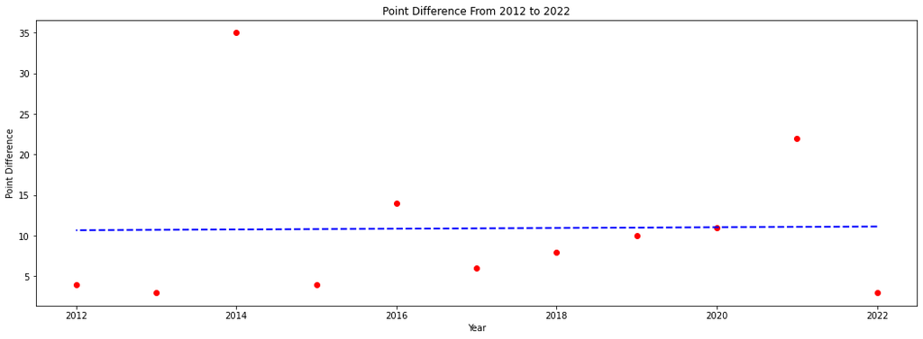

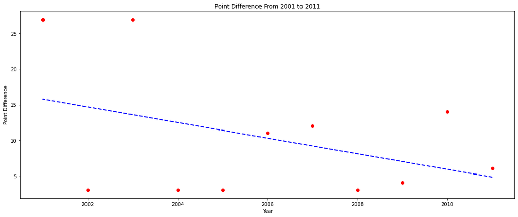

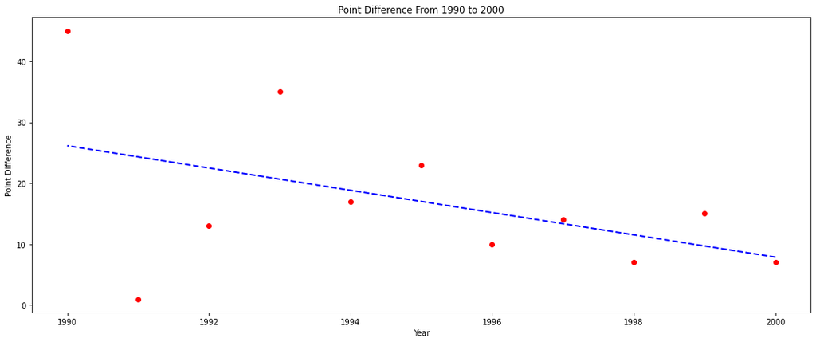

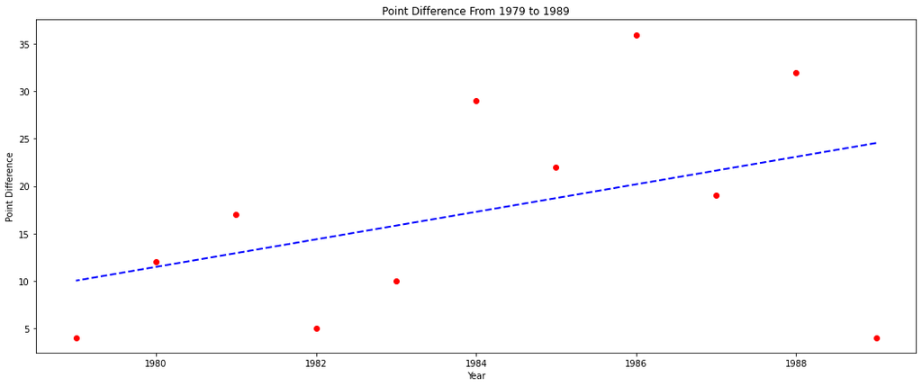

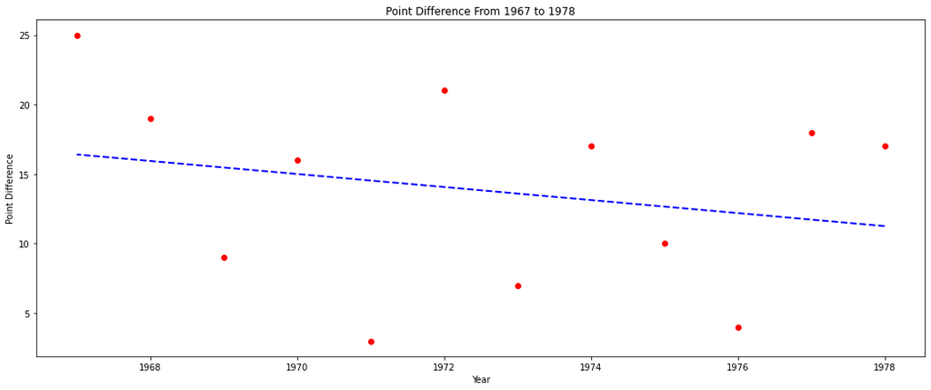

```python
# Plot Point Difference From 2012 to 2022
dates1=[]
diff1=[]
for i in range (0,11):
    dates1.append(2022-i)
    diff1.append(df.iloc[i,3] - df.iloc[i,5]*1.0)
x = np.array(dates1)
y = np.array(diff1)
a, b = np.polyfit(x, y, 1)
fig, ax = plt.subplots(figsize=(18,6))
plt.scatter(x, y, color='red')
plt.plot(x, a*x+b, color='blue', linestyle='--', linewidth=2)
ax.set_xlabel('Year')
ax.set_ylabel('Point Difference')
ax.set_title('Point Difference From 2012 to 2022')
plt.show()

# Plot Point Difference From 2001 to 2011
dates2=[]
diff2=[]
for i in range (11,22):
    dates2.append(2022-i)
    diff2.append(df.iloc[i,3] - df.iloc[i,5])
x = np.array(dates2)
y = np.array(diff2)
a, b = np.polyfit(x, y, 1)
fig, ax = plt.subplots(figsize=(18,7))
plt.scatter(x, y, color='red')
plt.plot(x, a*x+b, color='blue', linestyle='--', linewidth=2)
ax.set_xlabel('Year')
ax.set_ylabel('Point Difference')
ax.set_title('Point Difference From 2001 to 2011')
plt.show()

# Plot Point Difference From 1990 to 2000
dates3=[]
diff3=[]
for i in range (22,33):
    dates3.append(2022-i)
    diff3.append(df.iloc[i,3] - df.iloc[i,5])
x = np.array(dates3)
y = np.array(diff3)
a, b = np.polyfit(x, y, 1)
fig, ax = plt.subplots(figsize=(18,7))
plt.scatter(x, y, color='red')
plt.plot(x, a*x+b, color='blue', linestyle='--', linewidth=2)
ax.set_xlabel('Year')
ax.set_ylabel('Point Difference')
ax.set_title('Point Difference From 1990 to 2000')
plt.show()

# Plot Point Difference From 1979 to 1989
dates4=[]
diff4=[]
for i in range (33,44):
    dates4.append(2022-i)
    diff4.append(df.iloc[i,3] - df.iloc[i,5])
x = np.array(dates4)
y = np.array(diff4)
a, b = np.polyfit(x, y, 1)
fig, ax = plt.subplots(figsize=(18,7))
plt.scatter(x, y, color='red')
plt.plot(x, a*x+b, color='blue', linestyle='--', linewidth=2)
ax.set_xlabel('Year')
ax.set_ylabel('Point Difference')
ax.set_title('Point Difference From 1979 to 1989')
plt.show()

# Plot Point Difference From 1967 to 1978
dates5=[]
diff5=[]
for i in range (44,56):
    dates5.append(2022-i)
    diff5.append(df.iloc[i,3] - df.iloc[i,5])
x = np.array(dates5)
y = np.array(diff5)
a, b = np.polyfit(x, y, 1)
fig, ax = plt.subplots(figsize=(18,7))
plt.scatter(x, y, color='red')
plt.plot(x, a*x+b, color='blue', linestyle='--', linewidth=2)
ax.set_xlabel('Year')
ax.set_ylabel('Point Difference')
ax.set_title('Point Difference From 1967 to 1978')
plt.show()
```

```python
print("Mean Differential From 1967 to 1978: " + str(np.mean(diff5)))
print("Mean Differential From 1979 to 1989: " + str(np.mean(diff4)))
print("Mean Differential From 1990 to 2000: " + str(np.mean(diff3)))
print("Mean Differential From 2001 to 2011: " + str(np.mean(diff2)))
print("Mean Differential From 2012 to 2022: " + str(np.mean(diff1)))
```

```
Mean Differential From 1967 to 1978: 13.833333333333334
Mean Differential From 1979 to 1989: 17.272727272727273
Mean Differential From 1990 to 2000: 17.0
Mean Differential From 2001 to 2011: 10.272727272727273
Mean Differential From 2012 to 2022: 10.909090909090908
```

# Hypothesis Testing

The plots we have looked at thus far have shown some correlation between point differential and time, so lets present the hypothesis that as years increase, point differential will decrease. Therefore, the null hypothesis is that there is no correlation between point differential and time.

To test our hypothesis we will create a linear regression model that predicts the change in point differential per year. We will start by including data from all the years in our dataset (1967 - 2022).

```python
import statsmodels.formula.api as sm
from sklearn.linear_model import LinearRegression

table = pd.DataFrame({'year':dates,'diff':diff})

# Variables
X = np.array(table['year']).reshape(-1, 1)
Y = np.array(table['diff']).reshape(-1, 1)

reg = LinearRegression().fit(X,Y)
print(reg.coef_[0]) # slope
result = sm.ols(formula="diff ~ year", data=table).fit()
result.summary()
```

```
[-0.1215311]
```

OLS Regression Results

| Dep. Variable: | diff | R-squared: | 0.037 |
| --- | --- | --- | --- |
| Model: | OLS | Adj. R-squared: | 0.019 |
| Method: | Least Squares | F-statistic: | 2.081 |
| Date: | Fri, 16 Dec 2022 | Prob (F-statistic): | 0.155 |
| Time: | 04:40:28 | Log-Likelihood: | -208.44 |
| No. Observations: | 56 | AIC: | 420.9 |
| Df Residuals: | 54 | BIC: | 424.9 |
| Df Model: | 1 |  |  |
| Covariance Type: | nonrobust |  |  |

|  | coef | std err | t | P>\|t\| | [0.025 | 0.975] |
| --- | --- | --- | --- | --- | --- | --- |
| Intercept | 256.2509 | 168.030 | 1.525 | 0.133 | -80.628 | 593.130 |
| year | -0.1215 | 0.084 | -1.443 | 0.155 | -0.290 | 0.047 |

| Omnibus: | 10.710 | Durbin-Watson: | 2.422 |
| --- | --- | --- | --- |
| Prob(Omnibus): | 0.005 | Jarque-Bera (JB): | 10.678 |
| Skew: | 1.028 | Prob(JB): | 0.00480 |
| Kurtosis: | 3.589 | Cond. No. | 2.46e+05 |

Notes:  
[1] Standard Errors assume that the covariance matrix of the errors is correctly specified.  
[2] The condition number is large, 2.46e+05. This might indicate that there are  
strong multicollinearity or other numerical problems.

```python
table = pd.DataFrame({'year':dates2+dates3,'diff':diff2+diff3})

# Variables
X = np.array(table['year']).reshape(-1, 1)
Y = np.array(table['diff']).reshape(-1, 1)

reg = LinearRegression().fit(X,Y)
print(reg.coef_[0]) # slope
result = sm.ols(formula="diff ~ year", data=table).fit()
result.summary()
```

```
[-0.82326369]
```

OLS Regression Results

| Dep. Variable: | diff | R-squared: | 0.216 |
| --- | --- | --- | --- |
| Model: | OLS | Adj. R-squared: | 0.177 |
| Method: | Least Squares | F-statistic: | 5.524 |
| Date: | Fri, 16 Dec 2022 | Prob (F-statistic): | 0.0291 |
| Time: | 04:40:28 | Log-Likelihood: | -81.737 |
| No. Observations: | 22 | AIC: | 167.5 |
| Df Residuals: | 20 | BIC: | 169.7 |
| Df Model: | 1 |  |  |
| Covariance Type: | nonrobust |  |  |

|  | coef | std err | t | P>\|t\| | [0.025 | 0.975] |
| --- | --- | --- | --- | --- | --- | --- |
| Intercept | 1660.5754 | 700.736 | 2.370 | 0.028 | 198.865 | 3122.285 |
| year | -0.8233 | 0.350 | -2.350 | 0.029 | -1.554 | -0.093 |

| Omnibus: | 1.327 | Durbin-Watson: | 2.612 |
| --- | --- | --- | --- |
| Prob(Omnibus): | 0.515 | Jarque-Bera (JB): | 0.806 |
| Skew: | 0.466 | Prob(JB): | 0.668 |
| Kurtosis: | 2.895 | Cond. No. | 6.31e+05 |

Notes:  
[1] Standard Errors assume that the covariance matrix of the errors is correctly specified.  
[2] The condition number is large, 6.31e+05. This might indicate that there are  
strong multicollinearity or other numerical problems.

(Note that our linear regression models can only be used to predict Super Bowl point differentials in the near future, because the actual point differential will never drop below 1, and a decrease of 0.8233 every year would eventually result in a differential <1 which is impossible)

# Insights

[figure not shown]

The main insight we learned was that the scores between the winner and the loser of the Superbowl have become gradually closer since 1990. But why? As we discussed in the introduction, there have been many changes that have taken place in the NFL since its inaugural Super Bowl. One significant change was the introduction of the [salary cap](https://rugbydome.com/nfl-salary-cap/#:~:text=The%20NFL%20salary%20cap%20is%20a%20rule%20that,spend%20on%20player%20salaries%20in%20any%20given%20year.) in 1994. The salary cap sets a limit on the amount of money a team can spend on their roster during a given season. The purpose of this is to keep the talent level of teams relatively equal, so that there is no one team that can go on a spending spree and buy out all of the star players. Is this the primary cause of the Super Bowl point differential decreasing since the 1990s? I think yes. The salary cap prevents any team from becoming "too good," therefore the AFC championship team and the NFC championship team will produce a more competitive matchup in their Super Bowl meeting, thus creating closer scored games. However, we would need to do further testing to test the validity of this hypothesis.

One interesting resource reguarding the NFL salary cap is [spotrac](https://www.spotrac.com/nfl/positional/2021/quarterback/), which keeps track of NFL player salaries and their cap hit, meaning the percentage of the salary cap that the given player's salary consumes. Unfortunately, we are unable to collect most of this data because it lies behind a paywall. Hopefully in the future we will be able to access this data and perform data science on it to determine the true impact of the salary cap on NFL and Super Bowl scoring.